# Profil financier des municipalités locales du Québec

# Profil financier des municipalités locales du Québec

Données Québec / Ministère des Affaires municipales et de l'Habitation

Personne à contacter**Aurélien Nicosia**Révision pédagogique et statistique

Municipalité locale ou agglomération publiée dans le profil financier 2024-2025, données de 2025

Voir les résultats R[Source officielle](https://www.donneesquebec.ca/recherche/dataset/profil-financier-des-municipalites-locales)

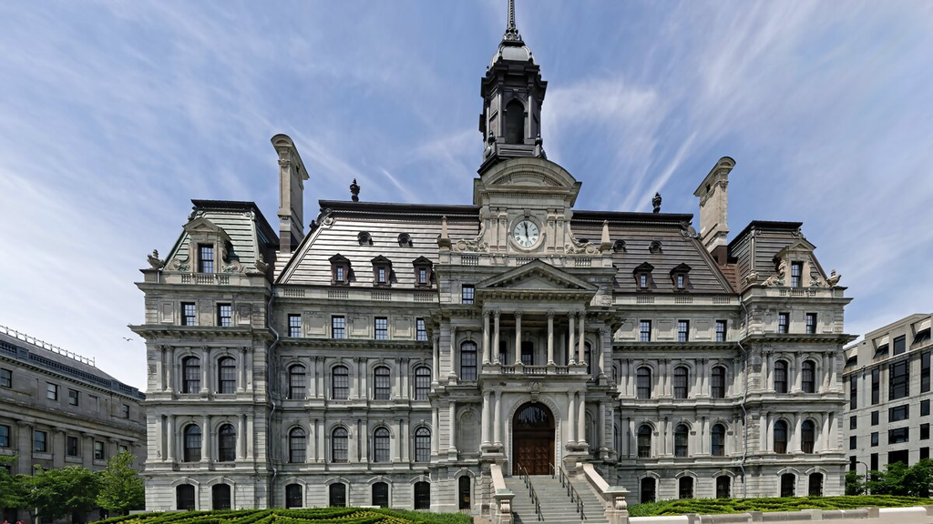

Territoire**Québec, municipalités locales et agglomérations publiées dans la ressource 2024-2025**

Niveau**Introduction à intermédiaire**

Structure**Table administrative financière, fiscale, foncière et territoriale**

Format**CSV officiel préparé localement; dictionnaire officiel des postes**

Question de départ

Comparer les indicateurs de richesse foncière selon les classes de population.

Potentiel pédagogique**27 / 30**

importation CSVdictionnaire de variablespivot longclasses de populationratiosindicesvaleurs manquantes

R en action

## Aperçu reproductible

Aperçu léger calculé par R à partir des métadonnées vérifiées afin de garder la fiche rapide et stable au rendu.

Code minimal

```r
library(yaml)

metadata <- yaml::read_yaml("datasets/budgets-municipaux-quebec/metadata.yml")
data.frame(
  champ = c("theme", "territoire", "unite", "niveau"),
  valeur = c(metadata$theme, metadata$geography, metadata$unit, metadata$level)
)
```

Résultats R

Lignes déclarées**1 105 municipalités ou agglomérations préparées; 15 470 lignes dans la version longue**

Colonnes déclarées**29 colonnes dans le CSV source; 31 colonnes dans la table municipale préparée**

Format**CSV officiel préparé localement; dictionnaire officiel des postes**

Aperçu**Métadonnées**

[output not shown]

Lecture statistique

Mini-projets

- Comparer les indicateurs de richesse foncière selon les classes de population.
- Visualiser les différences régionales sans confondre nombre de municipalités et population totale.
- Construire une version longue avec dictionnaire des postes et documenter les limites d'interprétation.

Activités liées

45-60 minutes**Profils fonciers par classe de population**

Comment la part résidentielle de l'évaluation imposable uniformisée varie-t-elle selon la classe de population?

2-3 heures**Portrait descriptif des profils financiers municipaux**

Comment décrire les profils financiers et fonciers des municipalités du Québec selon la classe de population et la région administrative?

## Pourquoi ce jeu est intéressant

Ce jeu est utile pour enseigner un réflexe central en science des données : lire la documentation avant d’analyser. Le titre courant parle souvent de finances municipales, mais le CSV préparé ici ne contient pas un budget détaillé par postes de dépenses. Il décrit plutôt le profil financier 2024-2025 des municipalités locales, avec des indicateurs issus du sommaire du rôle d’évaluation foncière 2025.

La valeur pédagogique est forte parce que les étudiants doivent relier trois tables : les municipalités, les classes de population et le dictionnaire des postes `FIALX`. On peut donc travailler l’importation de données ouvertes, le passage au format long, les ratios, les valeurs manquantes et la communication prudente.

Question d’analyse : comment les indicateurs de richesse foncière varient-ils selon la taille et la région des municipalités?

## Ce qui a été vérifié

| Élément | Résultat vérifié |
| --- | --- |
| Paquet CKAN | `b34de345-5bfe-4db2-a714-ed239a0c0b81` |
| Source officielle | Données Québec / Ministère des Affaires municipales et de l’Habitation |
| Ressources dans le paquet | 215 ressources |
| Ressource préparée ici | `PF-2024-2025.csv` |
| Dictionnaire préparé | `PF-2024-2025-DescriptionPoste.csv` |
| Profil | 2024-2025 |
| Année de la donnée | 2025 |
| Licence | Attribution (CC-BY 4.0), selon les métadonnées CKAN consultées le 2026-06-21 |
| Dernière modification du paquet CKAN | 2026-06-19 |
| Dernière modification du CSV municipal | 2026-06-19 |
| Table préparée | `data/processed/budgets-municipaux-quebec/profil_financier_municipalites_2025.csv` |
| Table longue préparée | `data/processed/budgets-municipaux-quebec/profil_financier_municipalites_long_2025.csv` |

## Source et conditions

| Champ | Information |
| --- | --- |
| Page Données Québec | https://www.donneesquebec.ca/recherche/dataset/profil-financier-des-municipalites-locales |
| API CKAN | https://www.donneesquebec.ca/recherche/api/3/action/package_show?id=profil-financier-des-municipalites-locales |
| CSV municipal officiel | https://mamh.gouv.qc.ca/fichiersdonneesouvertes/PF-2024-2025.csv |
| Dictionnaire officiel des postes | https://mamh.gouv.qc.ca/fichiersdonneesouvertes/PF-2024-2025-DescriptionPoste.csv |
| Page Québec.ca | https://www.quebec.ca/gouvernement/gestion-municipale/finances-fiscalite-municipales/information-financiere/publications-financieres/profil-financier |
| Territoire | Québec |
| Date d’accès | 2026-06-21 |
| Fréquence | Annuelle |
| Contact officiel indiqué par Québec.ca | `information.financiere@mamh.gouv.qc.ca` |

La page Québec.ca indique que le profil financier permet d’obtenir des données financières et fiscales, des ratios et des comparaisons avec différents groupes de municipalités. Elle précise aussi que certaines catégories de territoires ne sont pas publiées dans les profils, notamment les villages nordiques et plusieurs territoires autochtones.

## Ce que représente une ligne

Dans la table municipale préparée, une ligne représente une municipalité locale ou une agglomération publiée dans le fichier `PF-2024-2025.csv`.

Dans la table longue préparée, une ligne représente une combinaison `municipalité x indicateur financier`. Cette version est plus adaptée aux graphiques et aux exercices de nettoyage, car le dictionnaire officiel des postes donne le sens de chaque code `FIALX`.

Une ligne n’est pas un budget municipal complet, une dépense annuelle, une dette totale, ni une mesure de qualité de gestion municipale.

## Variables principales

| Variable préparée | Rôle | Point de vigilance |
| --- | --- | --- |
| `annee_edition` | Année du profil financier | Vaut 2024 dans la ressource préparée |
| `annee_donnee` | Année de la donnée source | Vaut 2025 dans la ressource préparée |
| `code_geographique` | Code géographique officiel | À conserver comme texte |
| `municipalite` | Nom de l’organisme municipal | Peut changer dans le temps |
| `region_administrative` | Région administrative | Utile pour les agrégations |
| `mrc` | MRC ou territoire équivalent | Manquant pour certains organismes |
| `population` | Population décrétée | Deux lignes n’ont pas de population publiée |
| `classe_population` | Classe de population | Variable principale pour une activité d’introduction |
| `FIALX01959` | RFU selon le dictionnaire officiel | Numérateur financier |
| `FIALX02005` | Part résidentielle de l’évaluation imposable uniformisée | Ratio publié |
| `FIALX02006` | Part industrielle et commerciale de l’évaluation imposable uniformisée | Ratio publié |
| `FIALX02007` | Part agricole de l’évaluation imposable uniformisée | Ratio publié |
| `FIALX02010` | Évaluation moyenne uniformisée par logement | Ratio publié |
| `FIALX02097` | Indice de RFU par unité d’évaluation imposable et compensable | Indice, pas un classement causal |

## RÉSULTATS R

| Indicateur | Valeur |
| --- | --- |
| Ressources CKAN documentées | 215 |
| Ressources préparées localement | 2 |
| Lignes dans le CSV municipal source | 1 105 |
| Colonnes dans le CSV municipal source | 29 |
| Municipalités ou agglomérations préparées | 1 105 |
| Indicateurs financiers municipaux `FIALX` | 14 |
| Lignes dans la version longue | 15 470 |
| Régions administratives représentées | 17 |
| MRC ou territoires équivalents représentés | 87 |
| Classes de population publiées | 5 |
| Lignes sans classe de population publiée | 2 |
| Population totale dans la table | 8 979 690 |
| Population minimale publiée | 9 |
| Population maximale publiée | 1 948 747 |

## Résumé par classe de population

| Classe de population | Municipalités | Population totale | Population médiane | Part résidentielle médiane | Part industrielle et commerciale médiane | Évaluation moyenne par logement médiane | Indice RFU médian |
| --- | --- | --- | --- | --- | --- | --- | --- |
| 0 à 1 999 | 698 | 600 239 | 772,5 | 65,29 | 7,14 | 218 836 | 100 |
| 2 000 à 9 999 | 292 | 1 213 456 | 3 316,5 | 74,62 | 8,87 | 287 702 | 100 |
| 10 000 à 24 999 | 66 | 1 046 362 | 14 834,0 | 83,53 | 10,47 | 385 930,5 | 100 |
| 25 000 à 99 999 | 36 | 1 677 850 | 42 534,5 | 81,77 | 15,24 | 401 188 | 100 |
| 100 000 et plus | 11 | 4 441 783 | 184 667,0 | 82,13 | 15,38 | 344 829 | 100 |
| Classe non publiée | 2 | 0 | NA | NA | NA | NA | 0 |

Lecture pédagogique : les classes plus populeuses ne sont pas simplement des versions agrandies des petites municipalités. Les parts résidentielles, industrielles et commerciales varient avec la taille, mais ces résultats sont descriptifs. Ils ne prouvent pas une cause.

## Régions les plus populeuses dans la table

| Région administrative | Municipalités | Population totale | Part résidentielle médiane | Indice RFU médian |
| --- | --- | --- | --- | --- |
| Montréal | 16 | 2 204 633 | 83,97 | 300,5 |
| Montérégie | 148 | 1 500 811 | 62,69 | 167,5 |
| Capitale-Nationale | 57 | 812 240 | 76,58 | 103,0 |
| Laurentides | 76 | 674 641 | 83,45 | 104,5 |
| Lanaudière | 57 | 559 061 | 79,00 | 111,0 |
| Estrie | 117 | 524 663 | 66,56 | 146,0 |

Cette table est utile pour discuter du poids démographique. Une région peut contenir beaucoup de municipalités sans représenter la plus grande population totale.

## Valeurs manquantes importantes

| Variable | Valeurs manquantes | Pourcentage |
| --- | --- | --- |
| `code_communaute_metropolitaine` | 996 | 90,14 % |
| `communaute_metropolitaine` | 996 | 90,14 % |
| `code_mrc` | 43 | 3,89 % |
| `mrc` | 43 | 3,89 % |
| `population` | 2 | 0,18 % |
| `classe_population` | 2 | 0,18 % |
| Plusieurs indicateurs `FIALX` | 4 | 0,36 % |

Les valeurs manquantes ne doivent pas être traitées automatiquement comme des zéros. Par exemple, l’absence de communauté métropolitaine indique surtout que la municipalité n’appartient pas à une communauté métropolitaine publiée dans cette colonne.

## Lecture statistique

Une analyse prudente suit cet ordre :

1. vérifier que l’unité est la municipalité ou l’agglomération publiée;
2. lire le dictionnaire des postes avant de renommer les variables `FIALX`;
3. distinguer population totale, nombre de municipalités et classes de population;
4. calculer des résumés descriptifs par classe ou par région;
5. repérer les valeurs manquantes;
6. éviter de présenter les indices comme des mesures de performance municipale.

Les données permettent de décrire des profils financiers publiés par le MAMH. Elles ne permettent pas, seules, d’expliquer pourquoi une municipalité a un profil foncier différent, ni d’évaluer la qualité de son administration.

## Concepts enseignables

- importation d’un CSV officiel;
- documentation des variables avec un dictionnaire séparé;
- passage du format large au format long;
- regroupements par classe de population;
- médianes et valeurs extrêmes;
- comparaison descriptive;
- valeurs manquantes;
- interprétation prudente d’indices administratifs.

## Score zéro déchet

| Dimension | Score | Justification |
| --- | --- | --- |
| Contexte québécois | 3 | Données officielles sur les municipalités du Québec |
| Accessibilité pédagogique | 3 | Variables territoriales simples et classes de population |
| Qualité documentaire | 3 | Page officielle, API CKAN, CSV et dictionnaire des postes |
| Potentiel de nettoyage | 3 | Codes, dictionnaire, format long, valeurs manquantes |
| Potentiel de visualisation | 3 | Barres, boîtes à moustaches, facettes par région |
| Potentiel de statistique descriptive | 3 | Comparaisons naturelles par classe et région |
| Potentiel d’inférence | 1 | Inférence limitée sans plan complémentaire |
| Potentiel de modélisation | 2 | Modélisation descriptive possible, mais prudence nécessaire |
| Potentiel éthique | 3 | Communication publique sur des indicateurs municipaux |
| Réutilisabilité | 3 | Utile en introduction, visualisation et données ouvertes |

Total : 27 sur 30.

## Activité courte

En 45 à 60 minutes, comparer les profils fonciers par classe de population et expliquer pourquoi une médiane par groupe est plus lisible qu’une liste de 1 105 municipalités.

## Activité longue

En 2 à 3 heures, produire un portrait descriptif par classe de population et par région, avec table longue, dictionnaire des postes, valeurs manquantes et limites d’interprétation.

## Code R minimal

À exécuter depuis la racine du projet.

```r
# Load libraries
library(dplyr)
library(ggplot2)
library(readr)

# Prepare official CSV resources
source("datasets/budgets-municipaux-quebec/preparation.R")

# Import prepared data
municipalites <- read_csv(
  "data/processed/budgets-municipaux-quebec/profil_financier_municipalites_2025.csv",
  show_col_types = FALSE
)

# Summarise by population class
resume_classes <- municipalites |>
  group_by(classe_population) |>
  summarise(
    municipalites = n(),
    population_totale = sum(population, na.rm = TRUE),
    part_residentielle_mediane = median(FIALX02005, na.rm = TRUE),
    part_industrielle_commerciale_mediane = median(FIALX02006, na.rm = TRUE),
    .groups = "drop"
  )

resume_classes

# Visualise one indicator
ggplot(
  municipalites |> filter(!is.na(classe_population), !is.na(FIALX02005)),
  aes(x = classe_population, y = FIALX02005)
) +
  geom_boxplot(fill = "#8FC7D9", color = "#1F3B57", outlier.alpha = 0.35) +
  coord_flip() +
  labs(
    x = "Classe de population",
    y = "Part résidentielle publiée",
    title = "Part résidentielle de l'évaluation imposable uniformisée",
    subtitle = "Profil financier 2024-2025, données de 2025"
  )
```

## Limites et précautions

- Le CSV préparé ici provient du sommaire du rôle d’évaluation foncière 2025.
- Le fichier ne contient pas un budget municipal détaillé par postes de dépenses.
- Les noms de municipalités peuvent changer dans le temps.
- Certaines catégories de territoires ne sont pas publiées dans les profils financiers.
- Les classes de population simplifient fortement la structure municipale.
- Les ratios et indices doivent être interprétés avec le dictionnaire officiel des postes.
- Les comparaisons par région ou classe sont descriptives.

## Extensions

- Comparer les résultats avec et sans les municipalités de 100 000 habitants et plus.
- Faire une table longue et produire une facette par indicateur.
- Joindre une géographie régionale pour produire une carte agrégée.
- Comparer le profil 2025 à une année antérieure en réutilisant le même script.
- Rédiger une note méthodologique expliquant pourquoi le fichier ne mesure pas directement les dépenses.

## Références utilisées

- Données Québec. 2026. Profil financier des municipalités locales. https://www.donneesquebec.ca/recherche/dataset/profil-financier-des-municipalites-locales
- Données Québec. 2026. API CKAN du paquet Profil financier des municipalités locales. https://www.donneesquebec.ca/recherche/api/3/action/package_show?id=profil-financier-des-municipalites-locales
- Ministère des Affaires municipales et de l’Habitation. 2026. Profil financier des municipalités. https://www.quebec.ca/gouvernement/gestion-municipale/finances-fiscalite-municipales/information-financiere/publications-financieres/profil-financier